# Renewable Portfolio Standards (RPS) and Electricity Prices: An Exploratory Analysis

**Author:** Gavin Loyd  
**Course:** EDA & Visualization

## Project Overview

This analysis explores the relationship between state-level Renewable Portfolio Standards (RPS) policies and electricity prices in the United States from 2010-2023. Using data from multiple sources including the U.S. Energy Information Administration (EIA), Bureau of Economic Analysis (BEA), and U.S. Census Bureau, I investigate whether RPS mandates affect electricity costs for consumers.

I am very interested in energy policy and want to better understand the impact of renewable portfolio standards on electricity prices. The core political issue right now seems to be about affordability in all arenas. Energy and electricity are no different. I've seen many politicians, especially in Pennsylvania, argue about the role of affordability in electricity. Many opponents of renewable energy argue that renewables will increase the price of electricity because they are "unreliable" and require significant subsidies. Renewable energy advocates tend to argue that renewable energy is getting dramatically cheaper over time and will result in lower electricity bills for consumers. I want to explore this issue in more detail using data. I suspect there is a small price increase generally associated with RPS policies in the short-term. However, I believe there are confounders such as the kinds of states that tend to adopt RPS policies (wealthier, more urbanized, more environmentally conscious), and these states may already have higher electricity prices for reasons unrelated to the RPS itself. Therefore, I want to explore this relationship descriptively. Ideally, I'd like this analysis to help set the stage for a causal analysis project in the future that controls for confounders. In order to do that, I need to understand the basic distributions and trends in the data first.

## Research Questions

1. **Do states with active RPS policies exhibit different electricity price distributions compared to states without RPS?**
2. **Is monthly electricity price volatility higher in state-years with RPS policies compared to those without?**
3. **How does the relationship between RPS targets and electricity prices differ across economic wealth levels (GDP per capita)?**
4. **Have electricity price trends diverged over time between RPS and non-RPS observations when controlling for state economic wealth?**
5. **How do electricity consumption patterns and costs vary across sectors (residential, commercial, industrial) in states with and without RPS policies?**

## Data Sources

This analysis combines **five data sources** to examine electricity prices and renewable energy policy across U.S. states from 2010-2023:

**1. Electricity Market Retail Sales Data ([EIA API](https://www.eia.gov/opendata/browser/electricity/retail-sales))**  
Monthly retail electricity statistics including price (cents/kWh), sales volume, revenue, and customer counts for all 50 states plus D.C., broken down by sector (residential, commercial, industrial, transportation).

**2. Renewable Portfolio Standards (RPS) Policy Data ([Lawrence Berkeley National Laboratory](https://emp.lbl.gov/sites/default/files/rps_ces_nominal_percentage_targets_june_2023.xlsx))**  
State-level requirements for renewable energy generation, showing which states have RPS policies and their target percentages by year. I created a binary indicator for whether each state had an active RPS policy.

**3. Economic Data ([Bureau of Economic Analysis](https://apps.bea.gov/itable/?ReqID=70&step=1))**  
State GDP figures used to calculate GDP per capita, which serves as a proxy for state wealth and cost of living.

**4. Population Data ([U.S. Census](https://www.census.gov/data/developers/data-sets/acs-5year.html))**  
Annual state population estimates from the American Community Survey 5-Year Estimates used to calculate GDP per capita.

**5. CPI Data ([Consumer Price Index Python Library](https://pypi.org/project/cpi/))**  
Consumer Price Index (CPI) data to adjust electricity prices for inflation, ensuring comparability over time.

**Final Dataset:**  
The merged dataset contains **42,840 observations**, where each row represents a specific state-month-sector combination with electricity market metrics, RPS policy status, and economic context. This structure enables comparison of electricity prices and consumption patterns between states with and without renewable energy mandates while accounting for economic differences. Due to a mismatch in available years after 2023 with some of the datasets, I decided to only use 2010-2023 for consistency across all data sources and to prevent missing data issues.

## Key Variables

- **Price:** Average retail electricity price (cents/kWh) by state, sector, and month
- **RPS Binary:** Indicator for whether a state has an active RPS policy in a given year
- **RPS Target:** Percentage of electricity generation required from renewable sources
- **GDP per Capita:** State economic output per person (proxy for wealth/cost of living)
- **Sector:** Residential, commercial, industrial, or transportation

## Methodology

1. Data collection and cleaning from multiple APIs and Excel files
2. Construction of state-month panel dataset (2010-2023)
3. Exploratory data analysis through visualizations and summary statistics

```python
# Standard library imports
import os
import time
import warnings

# Third-party imports
import requests
import pandas as pd
from dotenv import load_dotenv
from janitor import clean_names
import matplotlib.pyplot as plt
import seaborn as sns
from tqdm import tqdm
from census import Census
import cpi
import plotly.graph_objects as go
import plotly.io as pio
import matplotlib.pyplot as plt
import matplotlib.patches as mpatches
from matplotlib.collections import PatchCollection
import geopandas as gpd


# Load environment variables from .env file
load_dotenv()
```

```
True
```

## Data Collection and EDA

I started by collecting data from various sources mentioned above. My goal is to create a comprehensive dataset with electricity prices, renewable portfolio standards, and an economic indicator at the month-state level. Much of this data is structured in different ways, so I had to do some cleaning and transformation to make every dataset joinable.

### EIA Data Collection

First, I start with the Energy Information Administration API to get electricity retail rates. The API is a convenient way to grab this data, but it limits me to 5000 rows on each pull. Thus, I had to loop through multiple calls to get all the data I needed.

```python
# Paginate through API to get all rows

API_KEY_ELC = os.getenv("API_KEY_ELC")
assert API_KEY_ELC

BASE_URL = "https://api.eia.gov/v2/electricity/retail-sales/data/"
LENGTH = 5000

first_params = {
    "api_key": API_KEY_ELC,
    "frequency": "monthly",
    "data[0]": "customers",
    "data[1]": "price",
    "data[2]": "revenue",
    "data[3]": "sales",
    "start": "2010-01",
    "end": "2023-12",
    "sort[0][column]": "period",
    "sort[0][direction]": "desc",
    "offset": 0,
    "length": LENGTH,
}


def get_api_page(params):
    for _ in range(5):  # Simple retry
        r = requests.get(BASE_URL, params=params, timeout=60)
        if r.status_code == 429:
            time.sleep(1)
            continue
        r.raise_for_status()
        return r.json()
    raise RuntimeError("API GET failed after retries.")


# Get total from first query (for progress)
j = get_api_page(first_params)
total = int(j["response"]["total"])
print(f"Total rows expected: {total}")

records = j["response"]["data"]
got = len(records)

# Progressively fetch next pages
with tqdm(total=total, initial=got) as pbar:
    while got < total:
        params = first_params.copy()
        params["offset"] = got
        resp = get_api_page(params)
        page = resp["response"]["data"]
        records.extend(page)
        got += len(page)
        pbar.update(len(page))

# Make DataFrame
df_elec = pd.DataFrame(records)
print(f"All data shape: {df_elec.shape}")
display(df_elec.head())

# Remove customers-units, price-units, revenue-units, sales-units columns
cols_to_drop = [col for col in df_elec.columns if col.endswith("-units")]
df_elec.drop(columns=cols_to_drop, inplace=True)
```

```
Total rows expected: 62496
```

```
All data shape: (62496, 13)
```

|  | period | stateid | stateDescription | sectorid | sectorName | customers | price | revenue | sales | customers-units | price-units | revenue-units | sales-units |
| --- | --- | --- | --- | --- | --- | --- | --- | --- | --- | --- | --- | --- | --- |
| 0 | 2023-12 | AK | Alaska | ALL | all sectors | 355023 | 22.17 | 125.94351 | 567.99891 | number of customers | cents per kilowatt-hour | million dollars | million kilowatt hours |
| 1 | 2023-12 | AK | Alaska | COM | commercial | 56920 | 21.16 | 50.35598 | 237.96068 | number of customers | cents per kilowatt-hour | million dollars | million kilowatt hours |
| 2 | 2023-12 | AK | Alaska | IND | industrial | 1175 | 20.55 | 24.34964 | 118.49458 | number of customers | cents per kilowatt-hour | million dollars | million kilowatt hours |
| 3 | 2023-12 | AK | Alaska | OTH | other | None | None | None | None | number of customers | cents per kilowatt-hour | million dollars | million kilowatt hours |
| 4 | 2023-12 | AK | Alaska | RES | residential | 296928 | 24.22 | 51.23789 | 211.54365 | number of customers | cents per kilowatt-hour | million dollars | million kilowatt hours |

#### EIA Data - Basic EDA

After collecting the EIA data, I perform basic exploratory data analysis. My goal here is to understand the data structure and identify missing values. The results are below. The biggest issue was a substantial amount of missing data. Upon reviewing my outputs, I noticed that every sector had the same amount of rows dedicated to it. This makes sense because the EIA data is intended to display all retail sales with subsets for each industry. Interestingly, the missing values per column exactly match the amount of rows a sector should have. This suggests there is a systematic null value issue in one of the sectors. My hypothesis is that this is the "Other" sector, given its vague categorization.

A seconday issue was that my numeric variables were not cast correctly. I had to convert them from strings to numeric types to facilitate my later analysis.

```python
# Basic exploration of df_elec

# 1. Shape and structure
print("Shape:", df_elec.shape)
print("\nColumn names and types:")
df_elec.dtypes

# 2. Data types of col
print(df_elec.dtypes)

# 3. First few rows
display(df_elec.head())

# 4. Check for missing values
print("\nMissing values:")
print(df_elec.isnull().sum())

# 5. Summary statistics for numeric columns
df_elec.describe()

# 6. Check unique values in categorical columns
print("\nUnique states:", df_elec["stateid"].nunique())
print("Unique sectors:", df_elec["sectorid"].unique())
print("Unique periods:", df_elec["period"].nunique())

# 7. Value counts for key categorical variables
print("\nSector distribution:")
df_elec["sectorid"].value_counts()
```

```
Shape: (62496, 9)

Column names and types:
period              object
stateid             object
stateDescription    object
sectorid            object
sectorName          object
customers           object
price               object
revenue             object
sales               object
dtype: object
```

|  | period | stateid | stateDescription | sectorid | sectorName | customers | price | revenue | sales |
| --- | --- | --- | --- | --- | --- | --- | --- | --- | --- |
| 0 | 2023-12 | AK | Alaska | ALL | all sectors | 355023 | 22.17 | 125.94351 | 567.99891 |
| 1 | 2023-12 | AK | Alaska | COM | commercial | 56920 | 21.16 | 50.35598 | 237.96068 |
| 2 | 2023-12 | AK | Alaska | IND | industrial | 1175 | 20.55 | 24.34964 | 118.49458 |
| 3 | 2023-12 | AK | Alaska | OTH | other | None | None | None | None |
| 4 | 2023-12 | AK | Alaska | RES | residential | 296928 | 24.22 | 51.23789 | 211.54365 |

```
Missing values:
period                  0
stateid                 0
stateDescription        0
sectorid                0
sectorName              0
customers           10416
price               10416
revenue             10416
sales               10416
dtype: int64

Unique states: 62
Unique sectors: ['ALL' 'COM' 'IND' 'OTH' 'RES' 'TRA']
Unique periods: 168

Sector distribution:
```

```
sectorid
ALL    10416
COM    10416
IND    10416
OTH    10416
RES    10416
TRA    10416
Name: count, dtype: int64
```

```python
# Cast to numeric types
numeric_cols = ["customers", "price", "revenue", "sales"]

for col in numeric_cols:
    df_elec[col] = pd.to_numeric(df_elec[col], errors="coerce")


# Verify the conversion
print("Data types after conversion:")
print(df_elec.dtypes)

# Check how many nulls were created by coercion
print("\nNull values after conversion:")
print(df_elec[numeric_cols].isnull().sum())
```

```
Data types after conversion:
period               object
stateid              object
stateDescription     object
sectorid             object
sectorName           object
customers           float64
price               float64
revenue             float64
sales               float64
dtype: object

Null values after conversion:
customers    10416
price        10416
revenue      10416
sales        10416
dtype: int64
```

#### Checking the nulls

I test my hypothesis by filtering for the nulls and checking the unique sectors represented in the null subset df. The results confirm my suspicion that all nulls are in the OTH (OTHER) sector. I drop this sector accordingly. Even if this data was not missing, I'd likely not use it in my analysis since it's not well defined and "Other" categories tend to be an order of magnitude smaller than the main sectors.

```python
# See what nulls look like
null_samples = df_elec[df_elec[numeric_cols].isnull().any(axis=1)].head(10)

# check if sectorid values for null_samples
print("Sector IDs for rows with nulls:")
print(null_samples["sectorid"].unique())

# Filter for OTH sector ids that have a value in price
df_elec[
    (df_elec["sectorid"].str.startswith("OTH")) & (df_elec["price"].notnull())
].shape


# Remove all OTH sectorid rows
df_elec = df_elec[~df_elec["sectorid"].str.startswith("OTH")]
print(f"Data shape after removing OTH sectors: {df_elec.shape}")

# Check outcome
print(df_elec[numeric_cols].isnull().sum())
```

```
Sector IDs for rows with nulls:
['OTH']
Data shape after removing OTH sectors: (52080, 9)
customers    0
price        0
revenue      0
sales        0
dtype: int64
```

#### Checking State Identifiers

Next, I check the unique state identifiers in the EIA dataset to confirm that all 50 states plus D.C. are present. They are, which means the dataset covers the full geographic scope needed for my analysis.

Because EIA datasets often include additional geographic categories, I create a state-mapping table and filter the data to surface any unexpected values. The extra identifiers that appear are not states but aggregate regional codes used by EIA (e.g., ENC, MAT, PACN, etc.). These represent multi-state Census or EIA regions. They are not relevant for my analysis, so I exclude them from the final dataset.

```python
# Review if non-US states are present and filter them out


# Get all US state abbreviations (50 states + DC)
all_states = [
    "AL",
    "AK",
    "AZ",
    "AR",
    "CA",
    "CO",
    "CT",
    "DE",
    "FL",
    "GA",
    "HI",
    "ID",
    "IL",
    "IN",
    "IA",
    "KS",
    "KY",
    "LA",
    "ME",
    "MD",
    "MA",
    "MI",
    "MN",
    "MS",
    "MO",
    "MT",
    "NE",
    "NV",
    "NH",
    "NJ",
    "NM",
    "NY",
    "NC",
    "ND",
    "OH",
    "OK",
    "OR",
    "PA",
    "RI",
    "SC",
    "SD",
    "TN",
    "TX",
    "UT",
    "VT",
    "VA",
    "WA",
    "WV",
    "WI",
    "WY",
    "DC",
]

# filter to show stateid values that arent in all_states
non_us_states = df_elec[~df_elec["stateid"].isin(all_states)]["stateid"].unique()
print("Non-US states found in data:", non_us_states)

# filter df_elec to only include these states in stateid
df_elec = df_elec[df_elec["stateid"].isin(all_states)]
print(f"Data shape after filtering to US states: {df_elec.shape}")
```

```
Non-US states found in data: ['ENC' 'ESC' 'MAT' 'MTN' 'NEW' 'PACC' 'PACN' 'SAT' 'US' 'WNC' 'WSC']
Data shape after filtering to US states: (42840, 9)
```

I need a clean set of merge columns. I need state and year to do this, so I create the year column by extracting it from the period column. Once the year column is constructed, I’m ready to move on to the RPS data, which I expect to be much dirtier.

```python
# Prep for merge with rps data by constructing a year variable using dt
df_elec["period"] = pd.to_datetime(df_elec["period"])
df_elec["year"] = df_elec["period"].dt.year

# check unique year values - Expect 2010-2025
print("Unique years in data:", df_elec["year"].unique())
```

```
Unique years in data: [2023 2022 2021 2020 2019 2018 2017 2016 2015 2014 2013 2012 2011 2010]
```

### RPS Data Collection

```python
# Clean up RPS data import: skip headers, set correct columns, get only Total RPS per state

# Read Excel, skipping the first 22 rows, using row 24 as header
rps_file = "rps_file.xlsx"
df_rps_clean = pd.read_excel(rps_file, header=24, sheet_name="RPS & CES Targets (%)")


# Show head of imported RPS data
display(df_rps_clean.head())
```

|  | State | Special Notes | RPS Tier or Carve Out | 2000 | 2001 | 2002 | 2003 | 2004 | 2005 | 2006 | 2007 | 2008 | 2009 | 2010 | 2011 | 2012 | 2013 | 2014 | 2015 | 2016 | 2017 | 2018 | 2019 | 2020 | 2021 | 2022 | 2023 | 2024 | 2025 | … |
| --- | --- | --- | --- | --- | --- | --- | --- | --- | --- | --- | --- | --- | --- | --- | --- | --- | --- | --- | --- | --- | --- | --- | --- | --- | --- | --- | --- | --- | --- | --- |
| 0 | AZ | RPS applies only to IOUs and coops | Total RPS | 0.0 | 0.002 | 0.004 | 0.006000 | 0.008000 | 0.010000 | 0.012500 | 0.015000 | 0.017500 | 0.020000 | 0.025000 | 0.030000 | 0.035000 | 0.0400 | 0.045000 | 0.050000 | 0.060000 | 0.070000 | 0.080000 | 0.090000 | 0.100000 | 0.110000 | 0.120000 | 0.130000 | 0.140000 | 0.150000 | … |
| 1 | NaN | NaN | DG Carve-Out | 0.0 | 0.000 | 0.000 | 0.000000 | 0.000000 | 0.000000 | 0.000000 | 0.000000 | 0.001750 | 0.003000 | 0.005000 | 0.007500 | 0.010500 | 0.0120 | 0.013500 | 0.015000 | 0.018000 | 0.021000 | 0.024000 | 0.027000 | 0.030000 | 0.033000 | 0.036000 | 0.039000 | 0.042000 | 0.045000 | … |
| 2 | CA | Through 2015, the values shown here represent ... | Total RPS | 0.0 | 0.000 | 0.000 | 0.118525 | 0.128525 | 0.138525 | 0.148525 | 0.158525 | 0.168525 | 0.178525 | 0.200000 | 0.200000 | 0.200000 | 0.2000 | 0.217000 | 0.233000 | 0.250000 | 0.270000 | 0.290000 | 0.310000 | 0.330000 | 0.358000 | 0.385000 | 0.413000 | 0.440000 | 0.470000 | … |
| 3 | NaN | NaN | Total CES | 0.0 | 0.000 | 0.000 | 0.000000 | 0.000000 | 0.000000 | 0.000000 | 0.000000 | 0.000000 | 0.000000 | 0.000000 | 0.000000 | 0.000000 | 0.0000 | 0.000000 | 0.000000 | 0.000000 | 0.000000 | 0.000000 | 0.000000 | 0.000000 | 0.000000 | 0.000000 | 0.000000 | 0.000000 | 0.000000 | … |
| 4 | CO | CES is based on emission reduction target (80%... | Total RPS (Wtd. Avg.) | 0.0 | 0.000 | 0.000 | 0.000000 | 0.000000 | 0.000000 | 0.000000 | 0.030000 | 0.034568 | 0.034262 | 0.034204 | 0.084354 | 0.084922 | 0.0851 | 0.084973 | 0.144986 | 0.144233 | 0.143683 | 0.141886 | 0.140524 | 0.241539 | 0.241423 | 0.238955 | 0.238788 | 0.238788 | 0.238788 | … |

#### Flattening the RPS Dataset and Identifying State-Level Records

Most of the dataframe is unusable in this multi-nested format, and I do not need every variable this Excel data captures. I create a new dataframe by manually naming the columns to match the existing data. My review of the data indicates that IF a renewable portfolio standard exists, it appears in the first row for any given state. It is possible for other things to be the only "target type" for a state. I verify this by checking for rows where RPS is not in the same row as the state and then reviewing the surrounding rows. My review is correct.

*Note*: It seems that some states have different exemptions or special cases for applying the RPS. Parsing through every unique exception is outside the scope of this analysis, but it is important to recognize that these nuances exist. Not all RPS policies are created equal.

```python
# Clean cols
df_rps_clean = clean_names(df_rps_clean)


# filter to rows with state not null and 'total rps' substring in rps_tier_or_carve_out (case-insensitive)
mask = df_rps_clean["state"].notnull() & df_rps_clean[
    "rps_tier_or_carve_out"
].str.contains("total rps", case=False, na=False)
df_rps = df_rps_clean[mask].reset_index(drop=True)

# Store rows where state is not null but rps_tier_or_carve_out does not contain 'total rps'
invalid_rps_rows = df_rps_clean[
    df_rps_clean["state"].notnull()
    & ~df_rps_clean["rps_tier_or_carve_out"].str.contains(
        "total rps", case=False, na=False
    )
]

# Print each invalid row with context
for idx in invalid_rps_rows.index:
    print(f"\n{'=' * 80}")
    print(f"Invalid row at index {idx} (State: {df_rps_clean.loc[idx, 'state']})")
    print(f"{'=' * 80}")
    # Show 2 rows above, the row itself, and 7 rows below
    start_idx = max(0, idx - 2)  # Don't go below 0
    end_idx = idx + 8
    context_df = df_rps_clean.iloc[start_idx:end_idx]
    display(context_df)


# Remove special_notes AND rps_tier_or_carve_out columns
df_rps = df_rps.drop(
    columns=["special_notes", "rps_tier_or_carve_out"], errors="ignore"
)

# Show me header
display(df_rps.head())
```

```
================================================================================
Invalid row at index 84 (State: NE)
================================================================================
```

|  | state | special_notes | rps_tier_or_carve_out | 2000 | 2001 | 2002 | 2003 | 2004 | 2005 | 2006 | 2007 | 2008 | 2009 | 2010 | 2011 | 2012 | 2013 | 2014 | 2015 | 2016 | 2017 | 2018 | 2019 | 2020 | 2021 | 2022 | 2023 | 2024 | 2025 | … |
| --- | --- | --- | --- | --- | --- | --- | --- | --- | --- | --- | --- | --- | --- | --- | --- | --- | --- | --- | --- | --- | --- | --- | --- | --- | --- | --- | --- | --- | --- | --- |
| 82 | NaN | NaN | Poultry Waste Carve-Out | 0.0 | 0.0 | 0.0 | 0.0 | 0.0 | 0.0 | 0.0 | 0.0 | 0.000 | 0.000 | 0.0000 | 0.0000 | 0.0000 | 0.000 | 0.001312 | 0.001279 | 0.001272 | 0.001267 | 0.002286 | 0.003621 | 0.005139 | 0.002304 | 0.005167 | 0.006475 | 0.006773 | 0.006589 | … |
| 83 | NaN | NaN | Total CES (Duke only) | 0.0 | 0.0 | 0.0 | 0.0 | 0.0 | 0.0 | 0.0 | 0.0 | 0.000 | 0.000 | 0.0000 | 0.0000 | 0.0000 | 0.000 | 0.000000 | 0.000000 | 0.000000 | 0.000000 | 0.000000 | 0.000000 | 0.000000 | 0.000000 | 0.000000 | 0.000000 | 0.000000 | 0.000000 | … |
| 84 | NE | CES applies to Lincoln Electric System, Nebras... | Total CES (Wtd. Avg.) | 0.0 | 0.0 | 0.0 | 0.0 | 0.0 | 0.0 | 0.0 | 0.0 | 0.000 | 0.000 | 0.0000 | 0.0000 | 0.0000 | 0.000 | 0.000000 | 0.000000 | 0.000000 | 0.000000 | 0.000000 | 0.000000 | 0.000000 | 0.000000 | 0.000000 | 0.000000 | 0.000000 | 0.000000 | … |
| 85 | NaN | NaN | Lincoln Electric | 0.0 | 0.0 | 0.0 | 0.0 | 0.0 | 0.0 | 0.0 | 0.0 | 0.000 | 0.000 | 0.0000 | 0.0000 | 0.0000 | 0.000 | 0.000000 | 0.000000 | 0.000000 | 0.000000 | 0.000000 | 0.000000 | 0.000000 | 0.000000 | 0.000000 | 0.000000 | 0.000000 | 0.000000 | … |
| 86 | NaN | NaN | Nebraska PPD and Omaha PPD | 0.0 | 0.0 | 0.0 | 0.0 | 0.0 | 0.0 | 0.0 | 0.0 | 0.000 | 0.000 | 0.0000 | 0.0000 | 0.0000 | 0.000 | 0.000000 | 0.000000 | 0.000000 | 0.000000 | 0.000000 | 0.000000 | 0.000000 | 0.000000 | 0.000000 | 0.000000 | 0.000000 | 0.000000 | … |
| 87 | NH | RPS does not apply to municipal utilities | Total RPS | 0.0 | 0.0 | 0.0 | 0.0 | 0.0 | 0.0 | 0.0 | 0.0 | 0.040 | 0.060 | 0.0754 | 0.0958 | 0.0555 | 0.058 | 0.072000 | 0.083000 | 0.085000 | 0.176000 | 0.187000 | 0.197000 | 0.147000 | 0.146000 | 0.150000 | 0.159000 | 0.173000 | 0.252000 | … |
| 88 | NaN | NaN | Class I (Non-Thermal) | 0.0 | 0.0 | 0.0 | 0.0 | 0.0 | 0.0 | 0.0 | 0.0 | 0.000 | 0.005 | 0.0100 | 0.0200 | 0.0300 | 0.038 | 0.046000 | 0.054000 | 0.056000 | 0.068000 | 0.075000 | 0.082000 | 0.089000 | 0.096000 | 0.103000 | 0.110000 | 0.119000 | 0.128000 | … |
| 89 | NaN | NaN | Class I (Thermal) | 0.0 | 0.0 | 0.0 | 0.0 | 0.0 | 0.0 | 0.0 | 0.0 | 0.000 | 0.000 | 0.0000 | 0.0000 | 0.0000 | 0.000 | 0.004000 | 0.006000 | 0.006000 | 0.010000 | 0.012000 | 0.014000 | 0.016000 | 0.018000 | 0.020000 | 0.022000 | 0.022000 | 0.022000 | … |
| 90 | NaN | NaN | Class II (Solar Carve-Out) | 0.0 | 0.0 | 0.0 | 0.0 | 0.0 | 0.0 | 0.0 | 0.0 | 0.000 | 0.000 | 0.0004 | 0.0008 | 0.0015 | 0.002 | 0.003000 | 0.003000 | 0.003000 | 0.003000 | 0.005000 | 0.006000 | 0.007000 | 0.007000 | 0.007000 | 0.007000 | 0.007000 | 0.007000 | … |
| 91 | NaN | NaN | Class III (Existing Biomass/Methane) | 0.0 | 0.0 | 0.0 | 0.0 | 0.0 | 0.0 | 0.0 | 0.0 | 0.035 | 0.045 | 0.0550 | 0.0650 | 0.0140 | 0.005 | 0.005000 | 0.005000 | 0.005000 | 0.080000 | 0.080000 | 0.080000 | 0.020000 | 0.010000 | 0.005000 | 0.005000 | 0.010000 | 0.080000 | … |

|  | state | 2000 | 2001 | 2002 | 2003 | 2004 | 2005 | 2006 | 2007 | 2008 | 2009 | 2010 | 2011 | 2012 | 2013 | 2014 | 2015 | 2016 | 2017 | 2018 | 2019 | 2020 | 2021 | 2022 | 2023 | 2024 | 2025 | 2026 | 2027 | … |
| --- | --- | --- | --- | --- | --- | --- | --- | --- | --- | --- | --- | --- | --- | --- | --- | --- | --- | --- | --- | --- | --- | --- | --- | --- | --- | --- | --- | --- | --- | --- |
| 0 | AZ | 0.0 | 0.0020 | 0.004 | 0.006000 | 0.008000 | 0.010000 | 0.012500 | 0.015000 | 0.017500 | 0.020000 | 0.025000 | 0.030000 | 0.035000 | 0.0400 | 0.045000 | 0.050000 | 0.060000 | 0.070000 | 0.080000 | 0.090000 | 0.100000 | 0.110000 | 0.120000 | 0.130000 | 0.140000 | 0.150000 | 0.150000 | 0.150000 | … |
| 1 | CA | 0.0 | 0.0000 | 0.000 | 0.118525 | 0.128525 | 0.138525 | 0.148525 | 0.158525 | 0.168525 | 0.178525 | 0.200000 | 0.200000 | 0.200000 | 0.2000 | 0.217000 | 0.233000 | 0.250000 | 0.270000 | 0.290000 | 0.310000 | 0.330000 | 0.358000 | 0.385000 | 0.413000 | 0.440000 | 0.470000 | 0.492000 | 0.520000 | … |
| 2 | CO | 0.0 | 0.0000 | 0.000 | 0.000000 | 0.000000 | 0.000000 | 0.000000 | 0.030000 | 0.034568 | 0.034262 | 0.034204 | 0.084354 | 0.084922 | 0.0851 | 0.084973 | 0.144986 | 0.144233 | 0.143683 | 0.141886 | 0.140524 | 0.241539 | 0.241423 | 0.238955 | 0.238788 | 0.238788 | 0.238788 | 0.238788 | 0.238788 | … |
| 3 | CT | 0.0 | 0.0625 | 0.065 | 0.070000 | 0.040000 | 0.045000 | 0.050000 | 0.065000 | 0.080000 | 0.090000 | 0.100000 | 0.110000 | 0.120000 | 0.1300 | 0.140000 | 0.155000 | 0.170000 | 0.185000 | 0.210000 | 0.235000 | 0.250000 | 0.265000 | 0.280000 | 0.300000 | 0.320000 | 0.340000 | 0.290000 | 0.300000 | … |
| 4 | DC | 0.0 | 0.0000 | 0.000 | 0.000000 | 0.000000 | 0.000000 | 0.000000 | 0.040000 | 0.045000 | 0.050000 | 0.055000 | 0.065000 | 0.075000 | 0.0900 | 0.105000 | 0.120000 | 0.135000 | 0.150000 | 0.165000 | 0.180000 | 0.200000 | 0.262500 | 0.325000 | 0.387500 | 0.450000 | 0.520000 | 0.590000 | 0.660000 | … |

#### Backfilling Missing RPS Data

RPS data is not inclusive of states without any comparable policy in the original list. It's important to have a full panel dataset or else my final dataset will only the inclusive of the world of states with renewable portfolio standards in at least one year, so I work to identify which states have no RPS data and backfil with 0s. The current data only includes 0s when the state in at least one year has a RPS.

```python
# Count unique states in state
unique_states = df_rps["state"].nunique()
print(f"Unique states in RPS data: {unique_states}")


# Find missing states
existing_states = df_rps["state"].unique()
missing_states = [s for s in all_states if s not in existing_states]
print(f"Missing states: {missing_states}")

# Get year columns (all columns except 'state')
year_cols = [col for col in df_rps.columns if col != "state"]

# Create DataFrame for missing states with zeros
missing_data = []
for state in missing_states:
    row = {"state": state}
    # Add zeros for all year columns
    for year in year_cols:
        row[year] = 0.0
    missing_data.append(row)

df_missing = pd.DataFrame(missing_data)

# Concatenate with existing data
df_rps_complete = (
    pd.concat([df_rps, df_missing], ignore_index=True)
    .sort_values("state")
    .reset_index(drop=True)
)

print(f"\nOriginal states: {len(existing_states)}")
print(f"Complete states: {df_rps_complete['state'].nunique()}")
display(df_rps_complete.head(10))
```

```
Unique states in RPS data: 32
Missing states: ['AL', 'AK', 'AR', 'FL', 'GA', 'ID', 'IN', 'KY', 'LA', 'MS', 'NE', 'ND', 'OK', 'SC', 'SD', 'TN', 'UT', 'WV', 'WY']

Original states: 32
Complete states: 51
```

|  | state | 2000 | 2001 | 2002 | 2003 | 2004 | 2005 | 2006 | 2007 | 2008 | 2009 | 2010 | 2011 | 2012 | 2013 | 2014 | 2015 | 2016 | 2017 | 2018 | 2019 | 2020 | 2021 | 2022 | 2023 | 2024 | 2025 | 2026 | 2027 | … |
| --- | --- | --- | --- | --- | --- | --- | --- | --- | --- | --- | --- | --- | --- | --- | --- | --- | --- | --- | --- | --- | --- | --- | --- | --- | --- | --- | --- | --- | --- | --- |
| 0 | AK | 0.0 | 0.0000 | 0.000 | 0.000000 | 0.000000 | 0.000000 | 0.000000 | 0.000000 | 0.000000 | 0.000000 | 0.000000 | 0.000000 | 0.000000 | 0.0000 | 0.000000 | 0.000000 | 0.000000 | 0.000000 | 0.000000 | 0.000000 | 0.000000 | 0.000000 | 0.000000 | 0.000000 | 0.000000 | 0.000000 | 0.000000 | 0.000000 | … |
| 1 | AL | 0.0 | 0.0000 | 0.000 | 0.000000 | 0.000000 | 0.000000 | 0.000000 | 0.000000 | 0.000000 | 0.000000 | 0.000000 | 0.000000 | 0.000000 | 0.0000 | 0.000000 | 0.000000 | 0.000000 | 0.000000 | 0.000000 | 0.000000 | 0.000000 | 0.000000 | 0.000000 | 0.000000 | 0.000000 | 0.000000 | 0.000000 | 0.000000 | … |
| 2 | AR | 0.0 | 0.0000 | 0.000 | 0.000000 | 0.000000 | 0.000000 | 0.000000 | 0.000000 | 0.000000 | 0.000000 | 0.000000 | 0.000000 | 0.000000 | 0.0000 | 0.000000 | 0.000000 | 0.000000 | 0.000000 | 0.000000 | 0.000000 | 0.000000 | 0.000000 | 0.000000 | 0.000000 | 0.000000 | 0.000000 | 0.000000 | 0.000000 | … |
| 3 | AZ | 0.0 | 0.0020 | 0.004 | 0.006000 | 0.008000 | 0.010000 | 0.012500 | 0.015000 | 0.017500 | 0.020000 | 0.025000 | 0.030000 | 0.035000 | 0.0400 | 0.045000 | 0.050000 | 0.060000 | 0.070000 | 0.080000 | 0.090000 | 0.100000 | 0.110000 | 0.120000 | 0.130000 | 0.140000 | 0.150000 | 0.150000 | 0.150000 | … |
| 4 | CA | 0.0 | 0.0000 | 0.000 | 0.118525 | 0.128525 | 0.138525 | 0.148525 | 0.158525 | 0.168525 | 0.178525 | 0.200000 | 0.200000 | 0.200000 | 0.2000 | 0.217000 | 0.233000 | 0.250000 | 0.270000 | 0.290000 | 0.310000 | 0.330000 | 0.358000 | 0.385000 | 0.413000 | 0.440000 | 0.470000 | 0.492000 | 0.520000 | … |
| 5 | CO | 0.0 | 0.0000 | 0.000 | 0.000000 | 0.000000 | 0.000000 | 0.000000 | 0.030000 | 0.034568 | 0.034262 | 0.034204 | 0.084354 | 0.084922 | 0.0851 | 0.084973 | 0.144986 | 0.144233 | 0.143683 | 0.141886 | 0.140524 | 0.241539 | 0.241423 | 0.238955 | 0.238788 | 0.238788 | 0.238788 | 0.238788 | 0.238788 | … |
| 6 | CT | 0.0 | 0.0625 | 0.065 | 0.070000 | 0.040000 | 0.045000 | 0.050000 | 0.065000 | 0.080000 | 0.090000 | 0.100000 | 0.110000 | 0.120000 | 0.1300 | 0.140000 | 0.155000 | 0.170000 | 0.185000 | 0.210000 | 0.235000 | 0.250000 | 0.265000 | 0.280000 | 0.300000 | 0.320000 | 0.340000 | 0.290000 | 0.300000 | … |
| 7 | DC | 0.0 | 0.0000 | 0.000 | 0.000000 | 0.000000 | 0.000000 | 0.000000 | 0.040000 | 0.045000 | 0.050000 | 0.055000 | 0.065000 | 0.075000 | 0.0900 | 0.105000 | 0.120000 | 0.135000 | 0.150000 | 0.165000 | 0.180000 | 0.200000 | 0.262500 | 0.325000 | 0.387500 | 0.450000 | 0.520000 | 0.590000 | 0.660000 | … |
| 8 | DE | 0.0 | 0.0000 | 0.000 | 0.000000 | 0.000000 | 0.000000 | 0.000000 | 0.000000 | 0.000000 | 0.000000 | 0.000000 | 0.000000 | 0.000000 | 0.0000 | 0.100000 | 0.115000 | 0.130000 | 0.145000 | 0.160000 | 0.175000 | 0.190000 | 0.200000 | 0.210000 | 0.220000 | 0.230000 | 0.240000 | 0.250000 | 0.255000 | … |
| 9 | FL | 0.0 | 0.0000 | 0.000 | 0.000000 | 0.000000 | 0.000000 | 0.000000 | 0.000000 | 0.000000 | 0.000000 | 0.000000 | 0.000000 | 0.000000 | 0.0000 | 0.000000 | 0.000000 | 0.000000 | 0.000000 | 0.000000 | 0.000000 | 0.000000 | 0.000000 | 0.000000 | 0.000000 | 0.000000 | 0.000000 | 0.000000 | 0.000000 | … |

#### Pivoting RPS Data

The RPS data is in wide format, with each year as a separate column. To facilitate merging with the EIA data, I pivot the RPS data to long format, creating a year column and an RPS target column. This transformation allows for easier merging based on state and year.

```python
# Pivot from wide to long format: state-year
df_rps_long = df_rps_complete.melt(
    id_vars=["state"], var_name="year", value_name="rps_target"
)

# Convert year to int
df_rps_long["year"] = pd.to_numeric(df_rps_long["year"], errors="coerce").astype(
    "Int64"
)

# Sort by state and year
df_rps_long = df_rps_long.sort_values(["state", "year"]).reset_index(drop=True)

# Check for nulls in DF
null_counts = df_rps_long.isnull().sum()
print("\nNull values in RPS long DataFrame:")
print(null_counts)
```

```
Null values in RPS long DataFrame:
state         0
year          0
rps_target    0
dtype: int64
```

#### Constructing an RPS Binary Variable

To facilitate future analysis, I create a binary variable for every state-year pair. If a state-year pair has a value greater than 0, it receives a 1 in the RPS binary column. I will use this extensively when comparing different policy environments. I also retain the RPS target variable so I can analyze the magnitude of RPS requirements in later numeric comparisons.

```python
# Create rps_binary = 1 if that specific state-year has rps_target > 0
df_rps_long["rps_binary"] = (df_rps_long["rps_target"] > 0).astype(int)

# Verify the distribution
print("State-year pairs with RPS (binary=1):", (df_rps_long["rps_binary"] == 1).sum())
print(
    "State-year pairs without RPS (binary=0):", (df_rps_long["rps_binary"] == 0).sum()
)

# Show sample
display(df_rps_long[["state", "year", "rps_target", "rps_binary"]].head(20))

# Check to see if there are any rows where rps_binary is 1 but rps_target is 0
df_rps_long[(df_rps_long["rps_binary"] == 1) & (df_rps_long["rps_target"] == 0)].shape
```

```
State-year pairs with RPS (binary=1): 1281
State-year pairs without RPS (binary=0): 1320
```

|  | state | year | rps_target | rps_binary |
| --- | --- | --- | --- | --- |
| 0 | AK | 2000 | 0.0 | 0 |
| 1 | AK | 2001 | 0.0 | 0 |
| 2 | AK | 2002 | 0.0 | 0 |
| 3 | AK | 2003 | 0.0 | 0 |
| 4 | AK | 2004 | 0.0 | 0 |
| 5 | AK | 2005 | 0.0 | 0 |
| 6 | AK | 2006 | 0.0 | 0 |
| 7 | AK | 2007 | 0.0 | 0 |
| 8 | AK | 2008 | 0.0 | 0 |
| 9 | AK | 2009 | 0.0 | 0 |
| 10 | AK | 2010 | 0.0 | 0 |
| 11 | AK | 2011 | 0.0 | 0 |
| 12 | AK | 2012 | 0.0 | 0 |
| 13 | AK | 2013 | 0.0 | 0 |
| 14 | AK | 2014 | 0.0 | 0 |
| 15 | AK | 2015 | 0.0 | 0 |
| 16 | AK | 2016 | 0.0 | 0 |
| 17 | AK | 2017 | 0.0 | 0 |
| 18 | AK | 2018 | 0.0 | 0 |
| 19 | AK | 2019 | 0.0 | 0 |

```
(0, 4)
```

### GDP Data Collection

The GDP data comes from the Bureau of Economic Analysis (BEA) and is in Excel format. The data is pretty clean but has the same header issue as the RPS data. I cut out unnecessary rows, including footers and the US aggregate row. Finally, I ensure I have a state column that is mergeable with the two-letter abbreviations in the previous datasets and do final null checks to ensure data quality.

```python
# GDP import

gdp_df = pd.read_excel("gdp_state_year.xlsx")

print(gdp_df.head())

# Remove rows 1-4
gdp_df = gdp_df.iloc[4:].reset_index(drop=True)

# Set first row as cols
gdp_df.columns = gdp_df.iloc[0]

# Remove first and second row (get rid of US total row)

gdp_df = gdp_df.iloc[2:].reset_index(drop=True)

# Remote footers in last 2 rows
gdp_df = gdp_df.iloc[:-2].reset_index(drop=True)


# For columns 4 onward, remove the .0 from year headers
gdp_df.columns = [
    str(col).replace(".0", "") if isinstance(col, float) else col
    for col in gdp_df.columns
]

# Create state abbreviation mapping

# Create state name to abbreviation mapping
state_name_to_abbr = {
    "Alabama": "AL",
    "Alaska": "AK",
    "Arizona": "AZ",
    "Arkansas": "AR",
    "California": "CA",
    "Colorado": "CO",
    "Connecticut": "CT",
    "Delaware": "DE",
    "Florida": "FL",
    "Georgia": "GA",
    "Hawaii": "HI",
    "Idaho": "ID",
    "Illinois": "IL",
    "Indiana": "IN",
    "Iowa": "IA",
    "Kansas": "KS",
    "Kentucky": "KY",
    "Louisiana": "LA",
    "Maine": "ME",
    "Maryland": "MD",
    "Massachusetts": "MA",
    "Michigan": "MI",
    "Minnesota": "MN",
    "Mississippi": "MS",
    "Missouri": "MO",
    "Montana": "MT",
    "Nebraska": "NE",
    "Nevada": "NV",
    "New Hampshire": "NH",
    "New Jersey": "NJ",
    "New Mexico": "NM",
    "New York": "NY",
    "North Carolina": "NC",
    "North Dakota": "ND",
    "Ohio": "OH",
    "Oklahoma": "OK",
    "Oregon": "OR",
    "Pennsylvania": "PA",
    "Rhode Island": "RI",
    "South Carolina": "SC",
    "South Dakota": "SD",
    "Tennessee": "TN",
    "Texas": "TX",
    "Utah": "UT",
    "Vermont": "VT",
    "Virginia": "VA",
    "Washington": "WA",
    "West Virginia": "WV",
    "Wisconsin": "WI",
    "Wyoming": "WY",
    "District of Columbia": "DC",
}

# Map GeoName to state abbreviation
gdp_df["state"] = gdp_df["GeoName"].map(state_name_to_abbr)

# Check for any unmapped states
unmapped = gdp_df[gdp_df["state"].isnull()]["GeoName"].unique()
if len(unmapped) > 0:
    print(f"Warning: Unmapped states: {unmapped}")

# Verify mapping worked
print(f"States mapped: {gdp_df['state'].notna().sum()}")
display(gdp_df[["GeoName", "state"]].head(10))

# Remove GEOfips and GeoName columns
gdp_df = gdp_df.drop(columns=["GeoFips", "GeoName"], errors="ignore")


# Pivot from wide to long format
gdp_long = gdp_df.melt(id_vars=["state"], var_name="year", value_name="gdp_millions")

# Convert year to int
gdp_long["year"] = pd.to_numeric(gdp_long["year"], errors="coerce").astype("Int64")

# Check for any nulls
print("Null values in GDP DataFrame:")
print(gdp_long.isnull().sum())
```

```
  SASUMMARY State annual summary statistics: personal income, GDP, consumer spending, price indexes, and employment  ... Unnamed: 28
0  Current-dollar gross domestic product (GDP) (M...                                                                 ...         NaN
1                        Bureau of Economic Analysis                                                                 ...         NaN
2                                        State or DC                                                                 ...         NaN
3                                                NaN                                                                 ...         NaN
4                                            GeoFips                                                                 ...      2024.0

[5 rows x 29 columns]
States mapped: 51
```

|  | GeoName | state |
| --- | --- | --- |
| 0 | Alabama | AL |
| 1 | Alaska | AK |
| 2 | Arizona | AZ |
| 3 | Arkansas | AR |
| 4 | California | CA |
| 5 | Colorado | CO |
| 6 | Connecticut | CT |
| 7 | Delaware | DE |
| 8 | District of Columbia | DC |
| 9 | Florida | FL |

```
Null values in GDP DataFrame:
state           0
year            0
gdp_millions    0
dtype: int64
```

### Population Data Collection

The population data from the U.S. Census Bureau API. I import it using the Census package wrapper for the API. After importing, I do basic EDA to check for nulls and verify my state number. I have more states than I expect, so I review the extras even if they'll be removed in later merging.

```python
API_KEY_CN = os.getenv("API_KEY_CN")
assert API_KEY_CN

c = Census(API_KEY_CN)

years = range(2010, 2024)  # 2010–2023
var = "B01003_001E"  # total population

rows = []

for yr in years:
    try:
        # Use ACS 5-year so every year exists (ACS1 is missing 2020 + latest year)
        data = c.acs5.state(("NAME", var), Census.ALL, year=yr)
    except Exception as e:
        print(f"Skipping {yr}: {e}")
        continue

    for row in data:
        rows.append({"year": yr, "state": row["NAME"], "population": int(row[var])})

state_pop = pd.DataFrame(rows).sort_values(["state", "year"])

# Basic dataframe exloration
print(state_pop.head())
print(state_pop.info())

# Check for unique states
print("Unique states in population data:", state_pop["state"].nunique())

# List unique states - Why 52? A: Puerto Rico + DC
print("States in population data:", state_pop["state"].unique())
```

```
     year    state  population
0    2010  Alabama     4712651
52   2011  Alabama     4747424
104  2012  Alabama     4777326
156  2013  Alabama     4799277
208  2014  Alabama     4817678
<class 'pandas.core.frame.DataFrame'>
Index: 728 entries, 0 to 726
Data columns (total 3 columns):
 #   Column      Non-Null Count  Dtype
---  ------      --------------  -----
 0   year        728 non-null    int64
 1   state       728 non-null    object
 2   population  728 non-null    int64
dtypes: int64(2), object(1)
memory usage: 22.8+ KB
None
Unique states in population data: 52
States in population data: ['Alabama' 'Alaska' 'Arizona' 'Arkansas' 'California' 'Colorado' 'Connecticut'
 'Delaware' 'District of Columbia' 'Florida' 'Georgia' 'Hawaii' 'Idaho'
 'Illinois' 'Indiana' 'Iowa' 'Kansas' 'Kentucky' 'Louisiana' 'Maine' 'Maryland'
 'Massachusetts' 'Michigan' 'Minnesota' 'Mississippi' 'Missouri' 'Montana'
 'Nebraska' 'Nevada' 'New Hampshire' 'New Jersey' 'New Mexico' 'New York'
 'North Carolina' 'North Dakota' 'Ohio' 'Oklahoma' 'Oregon' 'Pennsylvania'
 'Puerto Rico' 'Rhode Island' 'South Carolina' 'South Dakota' 'Tennessee'
 'Texas' 'Utah' 'Vermont' 'Virginia' 'Washington' 'West Virginia' 'Wisconsin'
 'Wyoming']
```

The population data uses full state names instead of two-letter abbreviations. To facilitate merging, I create a mapping table to convert full state names to their corresponding abbreviations.

```python
# Map stateid to state abbreviation
state_pop["stateid"] = state_pop["state"].map(state_name_to_abbr)

# Check for any unmapped states
unmapped = state_pop[state_pop["stateid"].isnull()]["stateid"].unique()
if len(unmapped) > 0:
    print(f"Warning: Unmapped states: {unmapped}")

# Verify mapping worked
print(f"States mapped: {state_pop['stateid'].notna().sum()}")
display(state_pop[["state", "stateid"]].sample(5).head(10))


# Remove state column
state_pop = state_pop.drop(columns=["state"], errors="ignore")

# Convert year to int
state_pop["year"] = pd.to_numeric(state_pop["year"], errors="coerce").astype("Int64")
```

|  | state | stateid |
| --- | --- | --- |
| 266 | New Jersey | NJ |
| 123 | Maine | ME |
| 125 | Massachusetts | MA |
| 693 | Kentucky | KY |
| 690 | Indiana | IN |

### Full Merge and Construction of Remaining Variables

#### Merging all datasets

With all the datasets prepared, I go one by one and left join them in on the base df_elec (EIA retail data). After merging, I check the antijoins to ensure no unexpected data loss. None occurs.

```python
# Merge df_elec with df_rps_long on state and year
df_merged = pd.merge(
    df_elec,
    df_rps_long,
    how="left",
    left_on=["stateid", "year"],
    right_on=["state", "year"],
)

# Show failed merges
failed_merges = df_merged[df_merged["rps_target"].isnull()][
    ["stateid", "year"]
].drop_duplicates()
print(f"\nFailed merges (should be none): {failed_merges.shape[0]}")


# Show values from failed_merge stateid
if not failed_merges.empty:
    print("Failed merge stateids:")
    print(failed_merges["stateid"].unique())
```

```
Failed merges (should be none): 0
```

```python
# Merge in gdp_df on state and year
df_final = pd.merge(
    df_merged,
    gdp_long,
    how="left",
    left_on=["stateid", "year"],
    right_on=["state", "year"],
)

# Show failed merges
failed_gdp_merges = df_final[df_final["gdp_millions"].isnull()][
    ["stateid", "year"]
].drop_duplicates()
print(f"\nFailed GDP merges (should be none): {failed_gdp_merges.shape[0]}")
```

```
Failed GDP merges (should be none): 0
```

```python
# Merge in state_pop on stateid and year
df_final = pd.merge(
    df_final,
    state_pop,
    how="left",
    left_on=["stateid", "year"],
    right_on=["stateid", "year"],
)

# Show failed merges
failed_pop_merges = df_final[df_final["population"].isnull()][
    ["stateid", "year"]
].drop_duplicates()
print(f"\nFailed population merges (should be none): {failed_pop_merges.shape[0]}")
```

```
Failed population merges (should be none): 0
```

#### GDP Per Capita Calculation

Using the newly merged data, I calculate GDP per capita by dividing state GDP by state population for each state-year pair. This variable will serve as a proxy for state wealth and cost of living in my analysis.

```python
# Construct GDP per capita
df_final["gdp_per_capita"] = (df_final["gdp_millions"] * 1_000_000) / df_final[
    "population"
]

# Check some example values
print("\nGDP per capita examples:")
display(
    df_final[["stateid", "year", "gdp_millions", "population", "gdp_per_capita"]].head(
        10
    )
)

# Remove population and gdp_millions columns (keep gdp_per_capita)
df_final = df_final.drop(columns=["population", "gdp_millions"], errors="ignore")
```

```
GDP per capita examples:
```

|  | stateid | year | gdp_millions | population | gdp_per_capita |
| --- | --- | --- | --- | --- | --- |
| 0 | AK | 2023 | 68232.7 | 733971 | 92963.754699 |
| 1 | AK | 2023 | 68232.7 | 733971 | 92963.754699 |
| 2 | AK | 2023 | 68232.7 | 733971 | 92963.754699 |
| 3 | AK | 2023 | 68232.7 | 733971 | 92963.754699 |
| 4 | AK | 2023 | 68232.7 | 733971 | 92963.754699 |
| 5 | AL | 2023 | 309543.8 | 5054253 | 61244.223429 |
| 6 | AL | 2023 | 309543.8 | 5054253 | 61244.223429 |
| 7 | AL | 2023 | 309543.8 | 5054253 | 61244.223429 |
| 8 | AL | 2023 | 309543.8 | 5054253 | 61244.223429 |
| 9 | AL | 2023 | 309543.8 | 5054253 | 61244.223429 |

#### Inflation Adjustment

None of my data is inflation adjusted. To fix this, I use a rough CPI adjustment factor to convert all dollar amounts to 2023 dollars. This adjustment is crucial for accurate comparisons over time, especially given the long time span of my dataset (2010-2023).

```python
# Make sure CPI is updated once
# cpi.update()

# Precompute inflation factor for each unique year in the dataset
unique_years = df_final["year"].unique()
factor_by_year = {yr: cpi.inflate(1.0, yr, to=2023) for yr in unique_years}

# Map the factor onto each row
df_final["inflation_factor"] = df_final["year"].map(factor_by_year)

# Apply the inflation factor vectorized
df_final["price"] = df_final["price"] * df_final["inflation_factor"]
df_final["revenue"] = df_final["revenue"] * df_final["inflation_factor"]
df_final["gdp_per_capita"] = df_final["gdp_per_capita"] * df_final["inflation_factor"]


# Remove inflation_factor column
df_final = df_final.drop(columns=["inflation_factor"], errors="ignore")
```

#### Merged Dataframe Basic EDA

With the final merged dataset constructed, I perform basic exploratory data analysis to understand the distributions and identify any remaining data quality issues. The results are below. Overall, the data looks good with no unexpected nulls or outliers. The numeric variables are well within expected ranges. This is to be expected, as much of the earlier EDA and cleaning work would have prevented leakage into this step. One thing that this analysis puts into perspective is the sheer size of these numbers relative to each other. Being mindful of unit scales will be important going forward.

```python
# Basic review of final merged dataset

# Overall structure
print("Merged dataset shape:", df_final.shape)
print("\nColumn names:")
print(df_final.columns.tolist())

# Remove stateid, stateDescription, and sectorName columns
df_final.drop(
    columns=["stateid", "stateDescription", "sectorName", "state_y"],
    inplace=True,
    errors="ignore",
)

# Rename state_x to state
df_final.rename(columns={"state_x": "state"}, inplace=True)

# put column order as state, year, period, sector id
cols_order = ["state", "year", "period", "sectorid"] + [
    col
    for col in df_final.columns
    if col not in ["state", "year", "period", "sectorid"]
]
df_final = df_final[cols_order]

# Overall structure
print(" ")
print("Merged dataset shape after pruning cols:", df_final.shape)
print("\nColumn names:")
print(df_final.columns.tolist())


# Check for nulls
null_summary = df_final.isnull().sum()
print("\nNull values in merged dataset:")
print(null_summary)


# del df_rps, df_rps_clean, df_rps_long, df_elec, df_merged, gdp_df, gdp_long, state_pop
del (
    df_rps,
    df_rps_clean,
    df_rps_long,
    df_elec,
    df_merged,
    gdp_df,
    gdp_long,
    state_pop,
    df_missing,
    df_rps_complete,
    failed_gdp_merges,
    failed_merges,
    mask,
    null_counts,
    null_samples,
    null_summary,
    failed_pop_merges,
)
```

```
Merged dataset shape: (42840, 15)

Column names:
['period', 'stateid', 'stateDescription', 'sectorid', 'sectorName', 'customers', 'price', 'revenue', 'sales', 'year', 'state_x', 'rps_target', 'rps_binary', 'state_y', 'gdp_per_capita']

Merged dataset shape after pruning cols: (42840, 11)

Column names:
['state', 'year', 'period', 'sectorid', 'customers', 'price', 'revenue', 'sales', 'rps_target', 'rps_binary', 'gdp_per_capita']

Null values in merged dataset:
state             0
year              0
period            0
sectorid          0
customers         0
price             0
revenue           0
sales             0
rps_target        0
rps_binary        0
gdp_per_capita    0
dtype: int64
```

```python
# Show df for final verification and sanity checking values
print(df_final.describe())
```

```
               year  ... gdp_per_capita
count  42840.000000  ...   42840.000000
mean    2016.500000  ...   75298.005012
min     2010.000000  ...   44348.057596
25%     2013.000000  ...   61985.588553
50%     2016.500000  ...   70739.647636
75%     2020.000000  ...   80738.059292
max     2023.000000  ...  259271.157111
std        4.031176  ...   28276.903588

[8 rows x 9 columns]
```

## Analysis

My goal in this section is to answer the research questions posed at the start of the notebook. I use a combination of visualizations and summary statistics to examine the relationship between RPS policies and electricity prices. I begin by comparing broad price differences between RPS and non-RPS states, then drill down into industry-level and state-level patterns to identify where the most meaningful divergences occur.

```python
# Set style for all plots
sns.set_style("whitegrid")
sns.set_palette("husl")

# Color palette
rps_colors = ["#3498db", "#e74c3c"]  # Blue for No RPS, Red for RPS
```

### Electricity Price Distributions by RPS Status

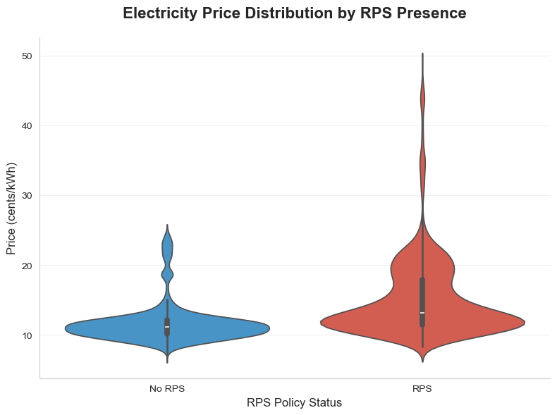

```python
# EDA for relationship between RPS and electricity prices

# 1. Violin plot - shows full distribution including outliers
# Filter to 'ALL' sector to avoid double-counting
fig, ax = plt.subplots(figsize=(8, 6))
vp = sns.violinplot(
    data=df_final[df_final["sectorid"] == "ALL"],
    x="rps_binary",
    y="price",
    hue="rps_binary",
    palette=rps_colors,
    ax=ax,
    legend=False,
)
ax.set_xticks([0, 1])
ax.set_xticklabels(["No RPS", "RPS"])
ax.set_title(
    "Electricity Price Distribution by RPS Presence",
    fontsize=16,
    fontweight="bold",
    pad=20,
)
ax.set_ylabel("Price (cents/kWh)", fontsize=12)
ax.set_xlabel("RPS Policy Status", fontsize=12)
ax.grid(axis="y", alpha=0.3)
ax.spines["top"].set_visible(False)
ax.spines["right"].set_visible(False)
plt.tight_layout()
plt.show()
```

To answer research question #1, I use a violin plot to compare electricity price distributions between RPS and non-RPS states across all sectors. The difference between the two groups is substantial. State-months with RPS policies are associated with noticeably higher electricity prices, and the entire RPS distribution appears shifted upward relative to the non-RPS distribution. The RPS group also exhibits much greater price dispersion, whereas the non-RPS group shows a comparatively tight cluster of observations. This indicates that prices in RPS states vary more widely.

Explaining the causality of this volatility is beyond the scope of this exploratory analysis, but two plausible mechanisms stand out:

1. Renewable generation is more dependent on weather conditions, and supply variability can induce short-term price swings.
2. States that adopt RPS policies may also have market structures that are inherently more volatile; less regulation, higher congestion, or higher-cost legacy systems.

While I cannot identify the causal mechanism here, I can quantify the volatility difference directly. To quantify price volatility differences between RPS and non-RPS states, I calculate the standard deviation of monthly electricity prices for each state-year pair. Then, I compare the average volatility across the two groups.

```python
# Monthly Price Volatility Analysis: Descriptive Statistics

# Filter to 'ALL' sector to avoid double-counting
df_volatility = df_final[df_final["sectorid"] == "ALL"].copy()

# Calculate volatility metrics by state-year
volatility_metrics = (
    df_volatility.groupby(["state", "year", "rps_binary"])
    .agg({"price": ["std", "mean", "min", "max", "count"]})
    .reset_index()
)

# Flatten column names
volatility_metrics.columns = [
    "state",
    "year",
    "rps_binary",
    "price_std",
    "price_mean",
    "price_min",
    "price_max",
    "n_months",
]

# Calculate additional metrics
volatility_metrics["price_range"] = (
    volatility_metrics["price_max"] - volatility_metrics["price_min"]
)
volatility_metrics["coefficient_of_variation"] = (
    volatility_metrics["price_std"] / volatility_metrics["price_mean"]
) * 100

print("=" * 90)
print("MONTHLY PRICE VOLATILITY ANALYSIS: RPS vs NON-RPS POLICY YEARS (2010-2023)")
print("=" * 90)

# Direct Comparison
print("\n" + "─" * 90)
print("DIRECT COMPARISON")
print("─" * 90)

no_rps_std = volatility_metrics[volatility_metrics["rps_binary"] == 0]["price_std"]
rps_std = volatility_metrics[volatility_metrics["rps_binary"] == 1]["price_std"]

median_diff = rps_std.median() - no_rps_std.median()
median_pct_diff = ((rps_std.median() / no_rps_std.median()) - 1) * 100

mean_diff = rps_std.mean() - no_rps_std.mean()
mean_pct_diff = ((rps_std.mean() / no_rps_std.mean()) - 1) * 100

print(f"\nMedian volatility:")
print(f"  Non-RPS: {no_rps_std.median():.4f} cents/kWh")
print(f"  RPS:     {rps_std.median():.4f} cents/kWh")
print(f"  Difference: {median_diff:.4f} cents/kWh ({median_pct_diff:+.1f}%)")

print(f"\nMean volatility:")
print(f"  Non-RPS: {no_rps_std.mean():.4f} cents/kWh")
print(f"  RPS:     {rps_std.mean():.4f} cents/kWh")
print(f"  Difference: {mean_diff:.4f} cents/kWh ({mean_pct_diff:+.1f}%)")

print(f"\nDistribution statistics:")
print(
    f"  Non-RPS IQR: {no_rps_std.quantile(0.75) - no_rps_std.quantile(0.25):.4f} cents/kWh"
)
print(f"  RPS IQR:     {rps_std.quantile(0.75) - rps_std.quantile(0.25):.4f} cents/kWh")
```

```
==========================================================================================
MONTHLY PRICE VOLATILITY ANALYSIS: RPS vs NON-RPS POLICY YEARS (2010-2023)
==========================================================================================

──────────────────────────────────────────────────────────────────────────────────────────
DIRECT COMPARISON
──────────────────────────────────────────────────────────────────────────────────────────

Median volatility:
  Non-RPS: 0.4361 cents/kWh
  RPS:     0.5666 cents/kWh
  Difference: 0.1305 cents/kWh (+29.9%)

Mean volatility:
  Non-RPS: 0.4726 cents/kWh
  RPS:     0.7069 cents/kWh
  Difference: 0.2343 cents/kWh (+49.6%)

Distribution statistics:
  Non-RPS IQR: 0.3154 cents/kWh
  RPS IQR:     0.6402 cents/kWh
```

#### Volatility Comparison Results

This deep dive into within-year volatility finds that state-years with an RPS have a median standard deviation of monthly retail prices that is about 0.13 cents/kWh higher than state-years without an RPS, roughly a 30% increase relative to the non-RPS group’s median. The mean difference in volatility is about twice as large as the median gap, consistent with a right-skewed distribution in which a small number of RPS state-years are much more volatile. This suggests that RPS policy years tend to feature higher within-year electricity price volatility and a small set of very volatile cases. It would be valuable to explore what drives this pattern, for example by mapping prices and RPS adoption over space and time to see if there is geographic clustering.

One speculative implication is that if renewable portfolio standards are associated with more variable price environments, the environments that often come in states with renewable portfolio standards could be complementary to battery storage build-out. Generally, renewable portfolio standards contain generation goals but renewable advocates also want battery build-out to support that generation. Even though this analysis uses monthly retail prices rather than high-frequency wholesale prices (which are more directly relevant for storage revenues), more volatile price environments generally create more opportunities for arbitrage and ancillary service revenues.

### Geographic Analysis

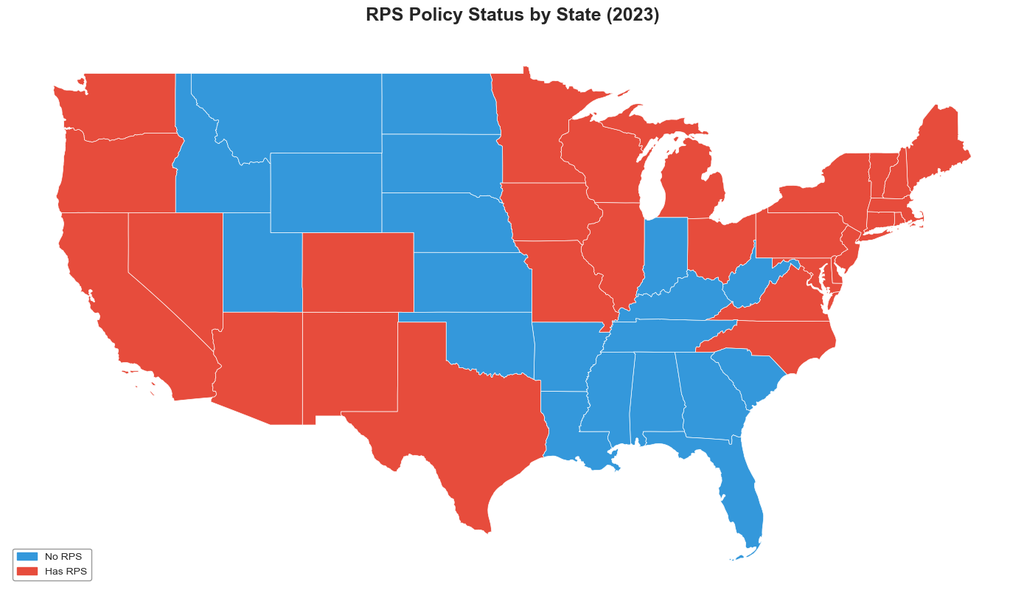

```python
# Geographic Analysis: RPS Status Map (2023) - Matplotlib Version

# Filter to 2023 data and 'ALL' sector
df_2023 = df_final[(df_final["year"] == 2023) & (df_final["sectorid"] == "ALL")].copy()

# Aggregate by state
state_summary_2023 = (
    df_2023.groupby("state")
    .agg({"rps_binary": "max", "price": "mean", "gdp_per_capita": "mean"})
    .reset_index()
)

try:
    gdf = gpd.read_file(
        "https://www2.census.gov/geo/tiger/GENZ2018/shp/cb_2018_us_state_20m.zip"
    )

    # Filter to continental US + DC
    gdf = gdf[~gdf["STUSPS"].isin(["AK", "HI", "PR", "VI", "GU", "MP", "AS"])]

    # Merge with your data
    gdf = gdf.merge(state_summary_2023, left_on="STUSPS", right_on="state", how="left")

    # Create map
    fig, ax = plt.subplots(figsize=(14, 8))

    # Color by RPS status
    gdf["color"] = gdf["rps_binary"].map({0: "#3498db", 1: "#e74c3c"})

    gdf.plot(ax=ax, color=gdf["color"], edgecolor="white", linewidth=0.5)

    # Styling
    ax.set_title(
        "RPS Policy Status by State (2023)", fontsize=18, fontweight="bold", pad=20
    )
    ax.axis("off")

    # Legend
    no_rps = mpatches.Patch(color="#3498db", label="No RPS")
    has_rps = mpatches.Patch(color="#e74c3c", label="Has RPS")
    ax.legend(
        handles=[no_rps, has_rps],
        loc="lower left",
        frameon=True,
        facecolor="white",
        edgecolor="gray",
    )

    plt.tight_layout()
    plt.show()

except Exception as e:
    print(f"Error loading shapefile: {e}")
    print("Please download US state boundaries.")
```

[figure not shown]

```python
# Geographic Analysis: Average Electricity Price Map (2010-2023)

# Calculate average price by state across ALL years
state_price_all_years = (
    df_final[df_final["sectorid"] == "ALL"]
    .groupby("state")
    .agg(
        {
            "price": "median",
            "rps_binary": "mean",  # Proportion of years with RPS
        }
    )
    .reset_index()
)



# Create map
fig, ax = plt.subplots(figsize=(14, 8))

# Calculate color scale limits (exclude top/bottom 5% to improve contrast)
price_min = state_price_all_years["price"].quantile(0.05)
price_max = state_price_all_years["price"].quantile(0.95)

# Plot with continuous color scale
gdf.plot(
    ax=ax,
    column="price",
    cmap="RdYlBu_r",  # Red=High, Blue=Low (reversed)
    vmin=price_min,
    vmax=price_max,
    edgecolor="white",
    linewidth=0.5,
    legend=True,
    legend_kwds={
        "label": "Median Price (cents/kWh)",
        "orientation": "vertical",
        "shrink": 0.6,
        "pad": 0.05,
    },
)

# Styling
ax.set_title(
    "Median Electricity Price by State (2010-2023)",
    fontsize=18,
    fontweight="bold",
    pad=20,
)
ax.axis("off")

plt.tight_layout()
plt.show()
```

[figure not shown]

```python
# Geographic Analysis: GDP Per Capita Map (2010-2023) - Matplotlib Version

# Calculate median GDP per capita by state across ALL years (2010-2023)
state_gdp_all_years = df_final[df_final['sectorid'] == 'ALL'].groupby('state').agg({
    'gdp_per_capita': 'median'
}).reset_index()


# Create map
fig, ax = plt.subplots(figsize=(14, 8))

# Calculate color scale limits (exclude top/bottom 5% to improve contrast)
gdp_min = state_gdp_all_years['gdp_per_capita'].quantile(0.05)
gdp_max = state_gdp_all_years['gdp_per_capita'].quantile(0.95)

    # Plot with continuous color scale
gdf.plot(
    ax=ax,
    column='gdp_per_capita',
    cmap='plasma',
    vmin=gdp_min,
    vmax=gdp_max,
    edgecolor='white',
    linewidth=0.5,
    legend=True,
    legend_kwds={
        'label': 'GDP per Capita (2023 dollars)',
        'orientation': 'vertical',
        'shrink': 0.6,
        'pad': 0.05
    }
)

    # Simplify colorbar ticks - show only min, middle, and max
cbar = ax.get_figure().axes[-1]  # Get the colorbar axis
tick_values = [gdp_min, (gdp_min + gdp_max) / 2, gdp_max]
cbar.set_yticks(tick_values)
cbar.set_yticklabels([f'${v:,.0f}' for v in tick_values])

# Styling
ax.set_title('Median GDP per Capita by State (2010-2023)',
                fontsize=18, fontweight='bold', pad=20)
ax.axis('off')

plt.tight_layout()
plt.show()
```

[output not shown]

##### Geographic Analysis - Results

A few things pop up between the maps.

California and the North East. Theses areas have higher electricity prices, RPS policies, and higher GDP per capita. This aligns with my expectation about wealthier states adopting RPS policies and having higher electricity prices.

However, there are high GDP states like Texas that have low electricity prices. Texas also has an RPS policy, but its electricity prices are much lower than other RPS states. Given that Texas has a deregulated electricity market orchestrated by ERCOT's unique market structure and Texas's RPS policy is relatively modest compared to other states, these results suggest a lot of noise between the relationship between electricity prices and renewable portfolio standards. However, I am still interested in exploring how GDP implicates this relationship more formally, so I'm going to explore that next.

### Electricity Prices vs. RPS Policy by GDP per Capita

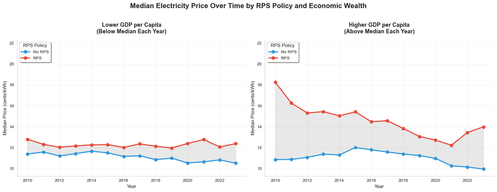

```python
# Time series faceted by GDP per capita (median split per year) - with dynamic median labels
# Filter to 'ALL' sector to avoid double-counting
df_plot = df_final[df_final["sectorid"] == "ALL"].copy()

# Calculate median GDP per capita FOR EACH YEAR separately
# Then classify states relative to their contemporaries
df_plot["gdp_group"] = df_plot.groupby("year")["gdp_per_capita"].transform(
    lambda x: x.apply(lambda val: "lower" if val < x.median() else "higher")
)


# Create faceted plot
fig, axes = plt.subplots(1, 2, figsize=(16, 6))

group_labels = {
    "lower": "Lower GDP per Capita\n(Below Median Each Year)",
    "higher": "Higher GDP per Capita\n(Above Median Each Year)",
}

for idx, (gdp_key, gdp_label) in enumerate(group_labels.items()):
    # Filter data for this GDP group
    df_subset = df_plot[df_plot["gdp_group"] == gdp_key]

    # Group by year and RPS
    df_grp = df_subset.groupby(["year", "rps_binary"])["price"].median().reset_index()

    # Pivot for plotting
    pivot_df = df_grp.pivot(index="year", columns="rps_binary", values="price")

    # Plot on appropriate axis
    ax = axes[idx]

    # Plot only where data exists
    if 0 in pivot_df.columns:
        ax.plot(
            pivot_df.index,
            pivot_df[0],
            marker="o",
            markersize=7,
            linewidth=2.5,
            label="No RPS",
            color=rps_colors[0],
        )

    if 1 in pivot_df.columns:
        ax.plot(
            pivot_df.index,
            pivot_df[1],
            marker="o",
            markersize=7,
            linewidth=2.5,
            label="RPS",
            color=rps_colors[1],
        )

    # Add fill_between only where BOTH series have data
    if 0 in pivot_df.columns and 1 in pivot_df.columns:
        both_exist = pivot_df[0].notna() & pivot_df[1].notna()
        ax.fill_between(
            pivot_df.index[both_exist],
            pivot_df[0][both_exist],
            pivot_df[1][both_exist],
            where=(pivot_df[1][both_exist] >= pivot_df[0][both_exist]),
            color="gray",
            alpha=0.18,
            interpolate=True,
        )

    # Styling
    ax.set_title(gdp_label, fontsize=13, fontweight="bold", pad=15)
    ax.set_ylabel("Median Price (cents/kWh)", fontsize=11)
    ax.set_xlabel("Year", fontsize=11)
    ax.legend(
        title="RPS Policy",
        fontsize=10,
        title_fontsize=11,
        frameon=True,
        shadow=True,
        loc="upper left",
    )
    ax.grid(True, alpha=0.3)
    ax.spines["top"].set_visible(False)
    ax.spines["right"].set_visible(False)

    # Set same y-axis limits for comparison
    ax.set_ylim(df_plot["price"].quantile(0.05), df_plot["price"].quantile(0.95))

plt.suptitle(
    "Median Electricity Price Over Time by RPS Policy and Economic Wealth",
    fontsize=16,
    fontweight="bold",
    y=1.02,
)
plt.tight_layout()
plt.show()
```

#### Electricity Prices vs. RPS Binary Policy by GDP per Capita - Results

I create a faceted line chart to see if there are difference pricing insights when you account for the wealth of a state. Within each year, I create a grouping for either side of the GDP median of prices and assign state-months accordingly. I emphasize the gap between the lines to highlight the differences in each scenario.

### RPS Targets vs. Electricity Prices by Wealth

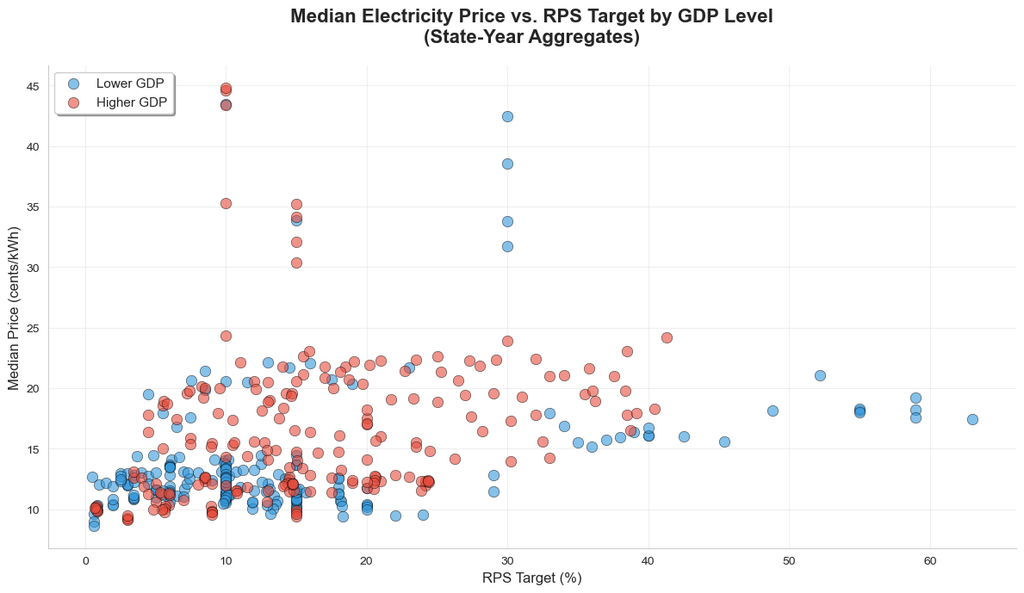

```
Correlation Matrix (RPS Target, Price, GDP per Capita):
                rps_target     price  gdp_per_capita
rps_target        1.000000  0.320869        0.116479
price             0.320869  1.000000        0.090020
gdp_per_capita    0.116479  0.090020        1.000000
```

```python
# Scatter plot with GDP (YEAR) grouping - simplified with trendlines
# Filter to 'ALL' sector to avoid double-counting
df_scatter = (
    df_final[df_final["sectorid"] == "ALL"]
    .groupby(["state", "year"])
    .agg({"rps_target": "median", "price": "median", "gdp_per_capita": "mean"})
    .reset_index()
)
df_scatter_filtered = df_scatter[df_scatter["rps_target"] > 0].copy()

# Add year-specific GDP grouping
df_scatter_filtered["gdp_group"] = df_scatter_filtered.groupby("year")[
    "gdp_per_capita"
].transform(
    lambda x: x.apply(lambda val: "Lower GDP" if val < x.median() else "Higher GDP")
)

# Define colors for GDP groups
gdp_colors = {"Lower GDP": "#3498db", "Higher GDP": "#e74c3c"}

fig, ax = plt.subplots(figsize=(12, 7))

# Plot each GDP group with its own color and trendline
for gdp_group in ["Lower GDP", "Higher GDP"]:
    mask = df_scatter_filtered["gdp_group"] == gdp_group

    # Scatter plot
    ax.scatter(
        df_scatter_filtered[mask]["rps_target"] * 100,
        df_scatter_filtered[mask]["price"],
        color=gdp_colors[gdp_group],
        alpha=0.6,
        s=80,
        edgecolors="black",
        linewidths=0.5,
        label=gdp_group,
    )


ax.legend(loc="upper left", fontsize=11, frameon=True, shadow=True)
ax.set_title(
    "Median Electricity Price vs. RPS Target by GDP Level\n(State-Year Aggregates)",
    fontsize=16,
    fontweight="bold",
    pad=20,
)
ax.set_xlabel("RPS Target (%)", fontsize=12)
ax.set_ylabel("Median Price (cents/kWh)", fontsize=12)
ax.grid(True, alpha=0.3)
ax.spines["top"].set_visible(False)
ax.spines["right"].set_visible(False)
plt.tight_layout()
plt.show()


# Correlation analysis
# Filter to 'ALL' sector and RPS_binary = 1
df_corr = df_final[
    (df_final["sectorid"] == "ALL") & (df_final["rps_binary"] == 1)
].copy()
corr_matrix = df_corr[["rps_target", "price", "gdp_per_capita"]].corr()
print("\nCorrelation Matrix (RPS Target, Price, GDP per Capita):")
print(corr_matrix)
```

#### RPS Targets vs. Electricity Prices by Wealth - Results

The resulting scatterplot shows a highly noisy relationship. The influence of state wealth appears much weaker here than in the earlier RPS-versus-non-RPS comparison, which is consistent with the possibility that wealthier states are disproportionately the ones adopting RPS policies to begin with. Once the sample is restricted to RPS states, the remaining wealth differences are smaller, and the visual separation largely disappears.

The trend is weak and nowhere near linear between rps_target and price. This, coupled with the previous binary variable work, suggests there is a weak association between RPS targets and prices with a few possible interpretations. A. much of the overall price gap between RPS and non-RPS states is driven by confounding factors unrelated to RPS targets themselves, and B. the presence of an RPS policy may matter more for price differences than incremental changes in the target percentage, if they matter at all relative to the confounders.

### Sectoral Analysis

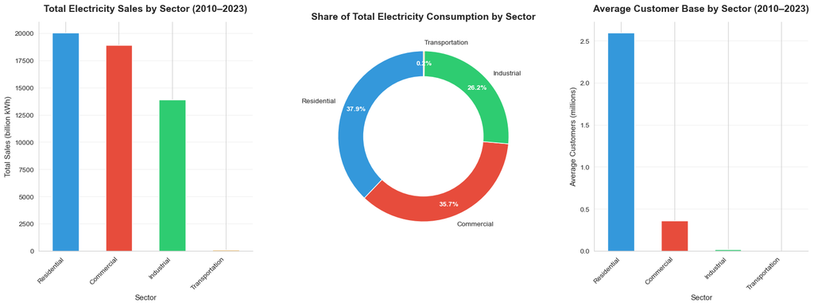

```
Sector Analysis Summary (2010–2023):
================================================================================

Residential:
  Sales: 20,042.6 billion kWh (37.9% of total)
  Customers: 2,596,471 (87.3% of total)
  Avg consumption per customer: 8 kWh/year

Commercial:
  Sales: 18,912.9 billion kWh (35.7% of total)
  Customers: 359,883 (12.1% of total)
  Avg consumption per customer: 53 kWh/year

Industrial:
  Sales: 13,871.1 billion kWh (26.2% of total)
  Customers: 17,269 (0.6% of total)
  Avg consumption per customer: 803 kWh/year

Transportation:
  Sales: 102.4 billion kWh (0.2% of total)
  Customers: 2 (0.0% of total)
  Avg consumption per customer: 55,744 kWh/year

================================================================================
Total Sales: 52,929.0 billion kWh
Total Customers: 2,973,625
```

```python
# Sectoral Analysis: Understanding Electricity Consumption Patterns

# Filter to sector data (exclude 'ALL')
df_sector = df_final[df_final["sectorid"] != "ALL"].copy()

# Convert from million kWh (raw EIA) to billion kWh for readability
df_sector["sales_billion_kwh"] = df_sector["sales"] / 1_000

sector_labels = {
    "RES": "Residential",
    "COM": "Commercial",
    "IND": "Industrial",
    "TRA": "Transportation",
}

# 1. Three-panel analysis: Sales, Share, and Customer Base
fig = plt.figure(figsize=(20, 6))
gs = fig.add_gridspec(1, 3, wspace=0.3)
ax1 = fig.add_subplot(gs[0, 0])
ax2 = fig.add_subplot(gs[0, 1])
ax3 = fig.add_subplot(gs[0, 2])

# Panel 1: Bar plot of total sales
sector_totals = (
    df_sector.groupby("sectorid")["sales_billion_kwh"]
    .sum()
    .sort_values(ascending=False)
)

colors = ["#3498db", "#e74c3c", "#2ecc71", "#f39c12"]
sector_totals.plot(kind="bar", ax=ax1, color=colors)

ax1.set_title(
    "Total Electricity Sales by Sector (2010–2023)",
    fontsize=14,
    fontweight="bold",
    pad=15,
)
ax1.set_xlabel("Sector", fontsize=11)
ax1.set_ylabel("Total Sales (billion kWh)", fontsize=11)
ax1.set_xticklabels(
    [sector_labels[s] for s in sector_totals.index], rotation=45, ha="right"
)
ax1.grid(axis="y", alpha=0.3)
ax1.spines["top"].set_visible(False)
ax1.spines["right"].set_visible(False)

# Panel 2: Donut chart of sector proportions
wedges, texts, autotexts = ax2.pie(
    sector_totals,
    labels=[sector_labels[s] for s in sector_totals.index],
    autopct="%1.1f%%",
    startangle=90,
    colors=colors,
    pctdistance=0.85,
)

centre_circle = plt.Circle((0, 0), 0.70, fc="white")
ax2.add_artist(centre_circle)

for autotext in autotexts:
    autotext.set_color("white")
    autotext.set_fontsize(10)
    autotext.set_weight("bold")

ax2.set_title(
    "Share of Total Electricity Consumption by Sector",
    fontsize=14,
    fontweight="bold",
    pad=15,
)


# Panel 3: Customer counts by sector
# Calculate average customers per sector across the entire period
customer_totals = (
    df_sector.groupby("sectorid")["customers"].mean().sort_values(ascending=False)
)
# Convert to millions for readability
customer_totals_millions = customer_totals / 1_000_000

# Reorder colors to match customer_totals order
color_map = dict(zip(sector_totals.index, colors))
customer_colors = [color_map[s] for s in customer_totals_millions.index]

customer_totals_millions.plot(kind="bar", ax=ax3, color=customer_colors)

ax3.set_title(
    "Average Customer Base by Sector (2010–2023)",
    fontsize=14,
    fontweight="bold",
    pad=15,
)
ax3.set_xlabel("Sector", fontsize=11)
ax3.set_ylabel("Average Customers (millions)", fontsize=11)
ax3.set_xticklabels(
    [sector_labels[s] for s in customer_totals_millions.index], rotation=45, ha="right"
)
ax3.grid(axis="y", alpha=0.3)
ax3.spines["top"].set_visible(False)
ax3.spines["right"].set_visible(False)

plt.show()

# Print comprehensive summary statistics
print("\nSector Analysis Summary (2010–2023):")
print("=" * 80)
total_sales = sector_totals.sum()
total_customers = customer_totals.sum()

for sector_id in sector_totals.index:
    sales = sector_totals[sector_id]
    customers = customer_totals[sector_id]
    sales_pct = (sales / total_sales) * 100
    customer_pct = (customers / total_customers) * 100

    print(f"\n{sector_labels[sector_id]}:")
    print(f"  Sales: {sales:,.1f} billion kWh ({sales_pct:.1f}% of total)")
    print(f"  Customers: {customers:,.0f} ({customer_pct:.1f}% of total)")
    print(f"  Avg consumption per customer: {(sales * 1000 / customers):,.0f} kWh/year")

print("\n" + "=" * 80)
print(f"Total Sales: {total_sales:,.1f} billion kWh")
print(f"Total Customers: {total_customers:,.0f}")
```

#### Sectoral Analysis - Results

To identify which sectors consume the most electricity and which groups may be most exposed to price increases, I create a bar chart and a pie chart showing sectoral shares of total electricity consumption. The results are straightforward. The residential, commercial, and industrial sectors each account for roughly similar proportions of total U.S. electricity use, while the transportation sector contributes only a negligible share. This is expected given that most transportation energy still comes from combustion fuels rather than electricity. Based on these patterns, I focus the remaining analysis on the three major sectors.

The minimal difference in consumption shares across the residential, commercial, and industrial sectors suggests that no single sector disproportionately drives electricity demand or uniquely bears the burden of higher prices. Price increases are likely to affect all three sectors in a broad way. This broad exposure may complicate the political landscape surrounding RPS policies. Although the residential sector holds only a slightly larger share of consumption, it has far more individual customers, each of whom directly experiences price changes. Many commercial and industrial users can partially buffer higher electricity costs through cost pass-through, operational scale, or efficiency improvements. If RPS policies are perceived as contributing to rising electricity prices, residential consumers may become the group most sensitive to these changes. More importantly, however, residential consumers have more "voices" in the political process through voting (as opposed to an arguably "louder" voice from the other sectors) This is a politically risky situation for RPS advocates. It is worth zooming out and seeing how dramatic *overall* price increases are to see if these marginal increases are meaningful in the grand scheme of things.

### Electricity Costs to Consumers Over Time Faceted by RPS/Non-RPS

[figure not shown]

```python
# 3. Sectoral electricity cost to consumers over time (faceted by RPS status)

# Aggregate revenue by sector, year, AND RPS status
sector_yearly_rev = (
    df_sector.groupby(["year", "sectorid", "rps_binary"])["revenue"].sum().reset_index()
)

# Convert to billions for better readability
sector_yearly_rev["revenue_billions"] = sector_yearly_rev["revenue"] / 1000

# Define sector colors
sector_colors = {"RES": "#3498db", "COM": "#e74c3c", "IND": "#2ecc71", "TRA": "#f39c12"}

sector_names = {
    "RES": "Residential",
    "COM": "Commercial",
    "IND": "Industrial",
    "TRA": "Transportation",
}

# Create two-panel plot
fig, axes = plt.subplots(1, 2, figsize=(18, 7))

rps_labels = {0: "States Without RPS", 1: "States With RPS"}

for idx, (rps_status, rps_label) in enumerate(rps_labels.items()):
    ax = axes[idx]

    # Filter data for this RPS status
    df_subset = sector_yearly_rev[sector_yearly_rev["rps_binary"] == rps_status]

    # Plot each sector (excluding TRA for better scale)
    for sector_id in ["RES", "COM", "IND"]:
        sector_data = df_subset[df_subset["sectorid"] == sector_id]
        ax.plot(
            sector_data["year"],
            sector_data["revenue_billions"],
            marker="o",
            markersize=6,
            linewidth=2.5,
            color=sector_colors[sector_id],
            label=sector_names[sector_id],
        )

    # Styling
    ax.set_title(rps_label, fontsize=14, fontweight="bold", pad=15)
    ax.set_xlabel("Year", fontsize=11)
    ax.set_ylabel("Total Cost (billion dollars)", fontsize=11)
    ax.legend(fontsize=10, frameon=True, shadow=True, loc="upper left")
    ax.grid(True, alpha=0.3)
    ax.spines["top"].set_visible(False)
    ax.spines["right"].set_visible(False)

    # Set same y-axis limits for comparison
    ax.set_ylim(
        0,
        sector_yearly_rev[sector_yearly_rev["sectorid"].isin(["RES", "COM", "IND"])][
            "revenue_billions"
        ].max()
        * 1.1,
    )

plt.suptitle(
    "Electricity Costs to Consumers by Major Sector and RPS Policy (2010-2023)",
    fontsize=16,
    fontweight="bold",
    y=1.02,
)

# Add notes about Transportation and shaded region
fig.text(
    0.5,
    -0.02,
    "Note: Transportation sector excluded due to minimal usage (<0.2% of total). Shaded area indicates 2020-2023 period.",
    ha="center",
    fontsize=9,
    style="italic",
    bbox=dict(boxstyle="round", facecolor="wheat", alpha=0.3),
)

plt.tight_layout()
plt.show()
```

## Conclusion

This project explored the relationship between renewable portfolio standards and electricity prices. The goal was to navigate a political discussion about affordability with data and evidence. The exploratory analysis uncovered a very noisy relationship that explains why it is such a contentious political discussion because it is very easy to cherry-pick one part of this exploratory work to support either side of the debate. Overall, it appears that states with RPS policies tend to have higher electricity price and greater price volatility. However, when you introduce other variables, such as GDP per capita, or map continous RPS targets over time relative to price, it becomes very clear that this relationship is noisy and confounded by other factors.

When you start looking at the consumers who would be affected by price changes, no one sector holds a disproportionate share of electricity consumption, with the caveat of the residential sector being made up of more *individuals.*

This exploratory analysis does not settle the debate. Instead, it sets the stage for causal analysis. It identifies that variables like state wealth need to be investigated with more rigor to isolate treatment effects of renewable portfolio standards.